# Typical year MAT effect and overlap

C. Susannah Tysor

10 March 2023

## MAT effect

The MAT of a tree’s provenance has a countergradient effect on flowering day of year. Trees from colder environments flower earlier than otherwise expected, while those from warmer environments flower later.

### in a common garden/seed orchard

When trees from different provenances are grown at the same site (in this case PGTIS), we expect all populations to flower at the same time. But the provenance effect causes flowering periods to be more different.

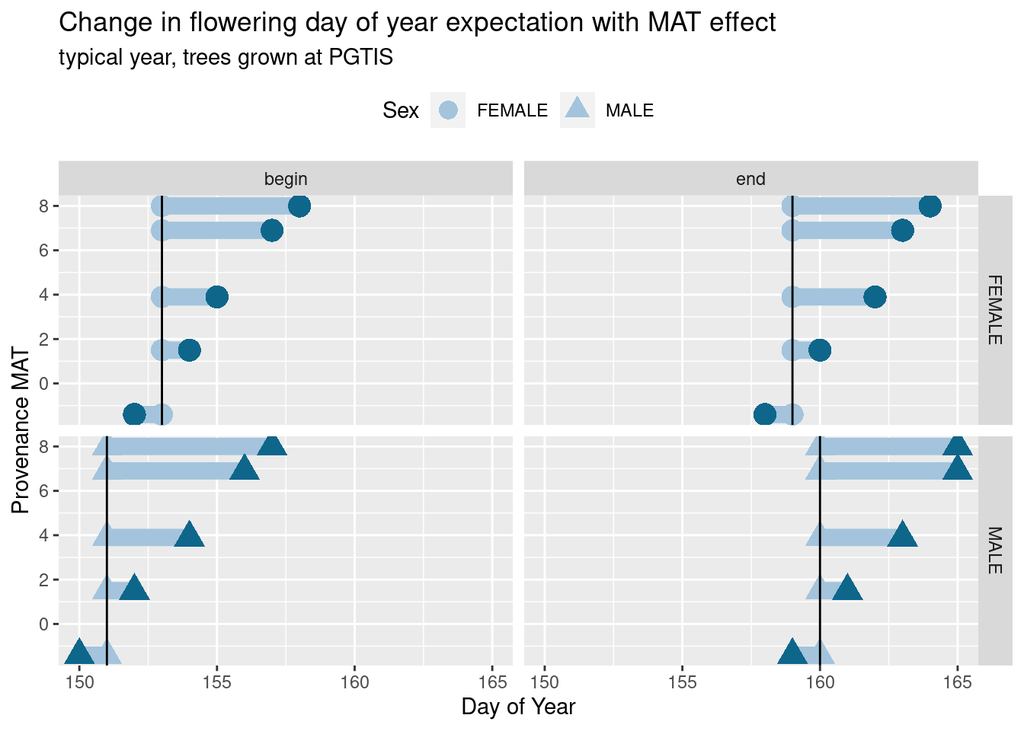

```
##   MAT_length noMAT_length
## 1         15            9
```

The overall length of the flowering period at a site planted with trees from multiple provenances is longer than it would be if provenance did not have an effect or if flowering varied positively with provenance MAT.

### On the landscape

While in a common garden (or seed orchard) the countergradient effect of provenance on flowering time pushes flowering periods apart, when trees are grown at their home sites have flowering periods to be drawn closer together than otherwise expected

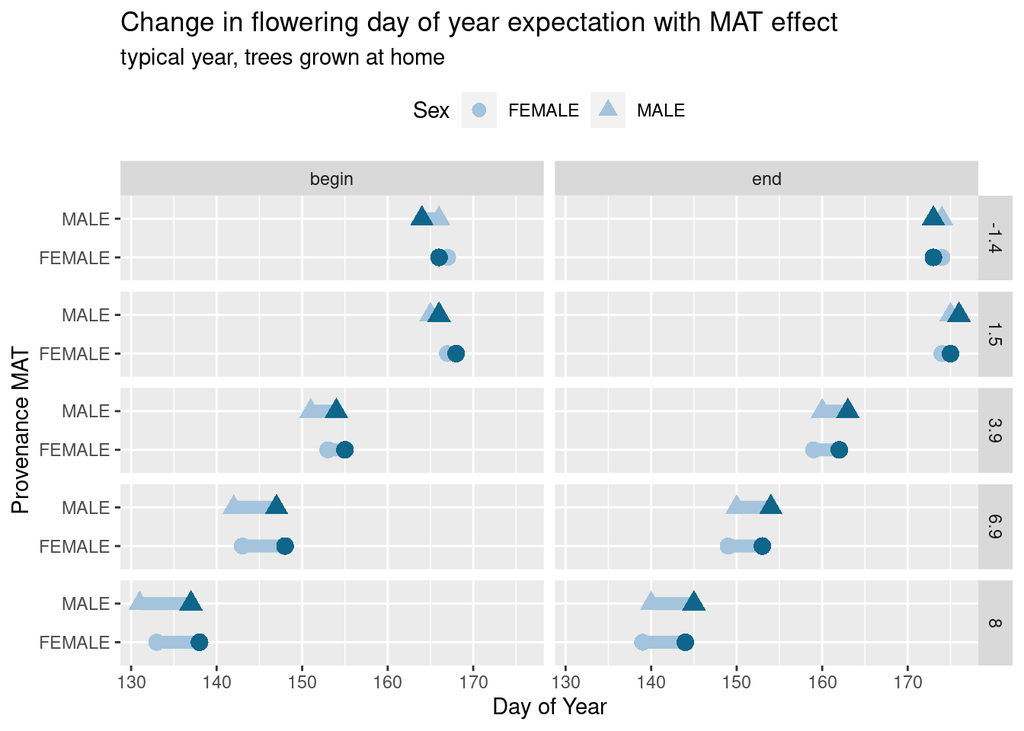

```
## # A tibble: 1 × 2
##   MAT_length noMAT_length
##        <dbl>        <dbl>
## 1         39           44
```

Countergradient variation reduces the length of the flowering period across the landscape.

## Overlap

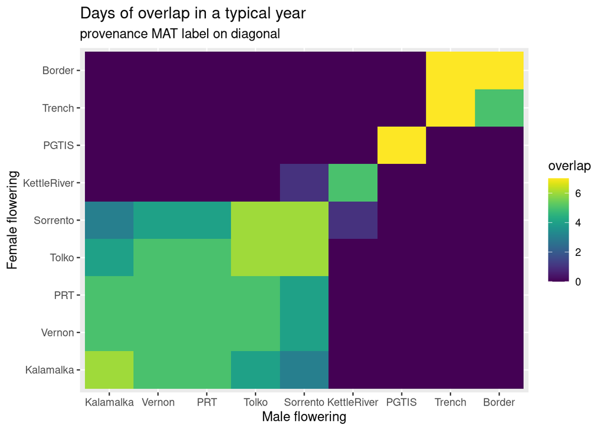

Overlap depends on both site and provenance climates. This overlap heatmap shows expected overlap when provenances are grown at home. Given very high levels of individual variation, I actually expect a bit more overlap, but this is the “mean” flowering period at each site.

```
##          Site  MAT
## 1      Border -1.4
## 2      Trench  1.5
## 3       PGTIS  3.9
## 4 KettleRiver  6.9
## 5    Sorrento  7.0
## 6       Tolko  7.3
## 7         PRT  7.6
## 8      Vernon  7.8
## 9   Kalamalka  8.0
```